# Conductivity Pipeline

## Introduction

This vignette walks through the complete conductivity processing pipeline using the `waterlogged` package. We use dummy data files from 3 sites/loggers to simulate how the package processes data from multiple stations simultaneously. We will then focus on simulated data from the **BUGS_WE_01** site to demonstrate the full QC pipeline.

The pipeline processes raw HOBO U24 conductivity logger data through these steps:

1. Read raw conductivity logger files (from multiple stations) and link them to deployment metadata
2. Run automatic quality checks (spikes, ice, dry sensor)
3. Visually review plots to identify problem periods
4. Convert electrical conductivity to specific conductance (SPC)
5. Make manual corrections as needed
6. Export the final clean dataset

**What is conductivity?** Electrical conductivity (EC) measures how well water conducts electricity, reported in microsiemens per centimetre (µS/cm). Higher conductivity means more dissolved ions (salts, minerals). It’s a quick indicator of water chemistry changes — runoff events, groundwater inputs, or pollution can all shift conductivity.

**Why temperature compensation?** Conductivity varies with water temperature — warmer water conducts better. To compare readings across seasons (or between sites at different temperatures), we normalize to a standard temperature (25 °C). This normalized value is called “specific conductance” (SPC) and is the standard for reporting.

This vignette assumes you have already installed `waterlogged`:

```r
install.packages("pak")
pak::pkg_install("dfo-pacific-science/waterlogged")
```

## Setup

```r
library(waterlogged)
```

Define paths to the test data shipped with the package.

```r
data_dir <- system.file("extdata", "conductivity", package = "waterlogged")
meta_dir <- system.file("extdata", "metadata", package = "waterlogged")

metadata_file   <- file.path(meta_dir, "metadata.csv")
cond_folder     <- file.path(data_dir, "raw")
```

## STEP 1: Bind Raw Conductivity Logger Files (v0.1)

Reads the raw HOBO U24 conductivity logger CSV and links it to the deployment metadata.

The HOBO U24 records two (or three) channels:

- Low Range conductivity (µS/cm) — used for most freshwater
- Full Range conductivity (µS/cm) — for higher conductivity water
- Water temperature (°C)

This step parses them into `conduct_uScm` and `watertemp_C`. When both Low and Full Range are present, the function selects the appropriate one and records the source in `conduct_source`.

**About the multi-station data:**

This script processes data from three separate HOBO U24 loggers at once:

```
- BUGS_WE_01 (cond-1.csv, SN 82345678): April 2024 to April 2025 (~1 year)
- BIRD_WE_01 (cond-2.csv, SN 89502162): April 2024 to August 2024 (~4 months)
- FISH_ST_01 (cond-3.csv, SN 88741256): October 2023 to October 2024 (~1 year)
```

Our primary focus for exploring the QC outputs will be **BUGS_WE_01**, which has a continuous deployment record in a wetland environment.

```r
cond_bound <- bind_logger_files(
  path_to_raw_folder = cond_folder,
  metadata_path      = metadata_file
)

cond_data <- cond_bound[[1]]
cond_plot <- cond_bound[[2]]
```

```
#> Conductivity data: 20286 rows
#> Stations: BIRD_WE_01, BUGS_WE_01, FISH_ST_01
#> Date range: 2023-10-18 13:00:00 to 2025-04-19 11:00:00
#> Conductivity range: 0.8 to 486.3 uS/cm
#> Water temp range: -1.3 to 40.1 deg C
```

```
#> Conductivity source channels used:
#>
#>  full   low
#>  8692 11594
```

```
#> # A tibble: 6 × 4
#>   timestamp           conduct_uScm watertemp_C site_station_code
#>   <dttm>                     <dbl>       <dbl> <chr>
#> 1 2024-04-19 15:00:00         172.       10.4  BIRD_WE_01
#> 2 2024-04-19 16:00:00         173.       10.5  BIRD_WE_01
#> 3 2024-04-19 17:00:00         172.       10.2  BIRD_WE_01
#> 4 2024-04-19 18:00:00         169.        9.48 BIRD_WE_01
#> 5 2024-04-19 19:00:00         165.        8.63 BIRD_WE_01
#> 6 2024-04-19 20:00:00         163.        8.16 BIRD_WE_01
```

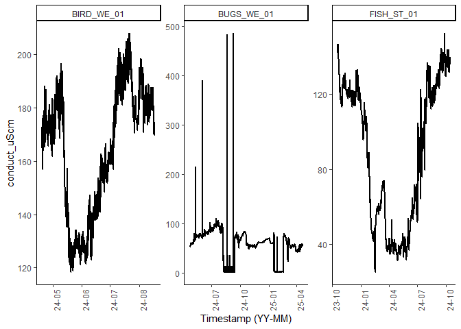

```r
cond_plot
```

## STEP 2: Automatic Conductivity QC

Runs automatic quality checks on the conductivity data and flags suspicious values.

Conductivity sensors can be affected by ice, air exposure (dry), or physical disturbances. This step catches common problems automatically.

What it checks:

1. **Spikes** — sudden large jumps in conductivity between consecutive readings (> `spike_flag_uScm`, default 200 µS/cm)
2. **Ice** — water temperature below 0.3 °C (sensor may be frozen)
3. **Temp range** — temperature outside plausible limits (< –2 or > 40 °C); these extreme values are converted to `NA`
4. **Conductivity range** — conductivity outside of plausible limits (< 0 or > 2500 µS/cm); the upper range should be set according to the specific calibration or measurement threshold of the logger (refer to device specifications).
5. **Dry sensor** — very low conductivity (<= `dry_flag_uScm`, default < 10 µS/cm) or air-water temp difference < 2 °C for a rolling 12-hour window

Adjusted columns created: `conduct_uScm_adj`, `watertemp_C_adj`.

```r
cond_qc <- qc_conductivity(
  input_data                 = cond_data,
  select_station             = "BUGS_WE_01",
  temp_low_limit_C           = -2,
  temp_high_limit_C          = 40,
  temp_ice_flag_C            = 0.3,
  spike_flag_uScm            = 200,
  dry_flag_uScm              = 10,
  temp_air_water_diff_C      = 2
)
```

[output not shown]

```
#>
#> QC log entries:
#> # A tibble: 58 × 5
#>    field            action  code       ts_start            ts_end
#>    <chr>            <chr>   <chr>      <dttm>              <dttm>
#>  1 conduct_uScm_adj AUTO_QC FLAG_SPIKE 2024-05-31 04:00:00 2024-05-31 05:00:00
#>  2 conduct_uScm_adj AUTO_QC FLAG_SPIKE 2024-08-19 20:00:00 2024-08-19 21:00:00
#>  3 conduct_uScm_adj AUTO_QC FLAG_SPIKE 2024-09-08 00:00:00 2024-09-08 01:00:00
#>  4 watertemp_C_adj  AUTO_QC FLAG_ICE   2025-01-17 02:00:00 2025-03-01 03:00:00
#>  5 watertemp_C_adj  AUTO_QC FLAG_ICE   2025-03-01 05:00:00 2025-03-01 05:00:00
#>  6 watertemp_C_adj  AUTO_QC FLAG_ICE   2025-03-01 07:00:00 2025-03-01 10:00:00
#>  7 watertemp_C_adj  AUTO_QC FLAG_ICE   2025-03-01 12:00:00 2025-03-01 15:00:00
#>  8 watertemp_C_adj  AUTO_QC FLAG_ICE   2025-03-01 17:00:00 2025-03-02 01:00:00
#>  9 watertemp_C_adj  AUTO_QC FLAG_ICE   2025-03-02 03:00:00 2025-03-02 04:00:00
#> 10 watertemp_C_adj  AUTO_QC FLAG_ICE   2025-03-02 06:00:00 2025-03-02 06:00:00
#> # ℹ 48 more rows
```

### OPTIONAL: Improve dry event detection by adding air temperature

Dry event detection can be refined and distinguished from ice events by adding continuous air temperature data, such as from a HOBO TidbiT or barometric pressure (U20) logger.

```r
baro_folder     <- file.path(data_dir, "baro")
baro_files      <- list.files(path = baro_folder, pattern = "\\.csv$", full.names = TRUE)
baro_filenames  <- basename(baro_files)

baro_data <- lapply(baro_files, read.csv) |>
  dplyr::bind_rows()
```

```
#> Found 2 CSV file(s):
#>  - BUGS_WE_01_BARO_2024_v1.0.csv
#>  - BUGS_WE_01_BARO_2025_v1.0.csv
#> Barometric data: 15835 rows
#> Stations: BUGS_WE_01
#> Date range: 1/1/2024 0:00:00 to 9/9/2025 9:00:00
#> Temperature range: -38.2 to 35.3 deg C
```

```r
cond_with_baro <- add_nearest_baro(
  input_data = cond_data,
  baro_data_path = baro_folder,
  metric = "conductivity",
  baro_site_selection = "auto",
  metadata_path = metadata_file
)

cond_airtemp <- cond_with_baro[[1]]
```

```r
cond_qc_at <- qc_conductivity(
  input_data                 = cond_airtemp,
  select_station             = "BUGS_WE_01",
  temp_low_limit_C           = -2,
  temp_high_limit_C          = 40,
  temp_ice_flag_C            = 0.3,
  spike_flag_uScm            = 200,
  dry_flag_uScm              = 10,
  temp_air_water_diff_C      = 2
)

cat("  Dry flagged:      ", sum(cond_qc_at$FLAG_DRY, na.rm = TRUE), "\n")
```

```
#>   Dry flagged:       258
```

## STEP 3: Visual Review

How to read the plot:

- Light traces = raw values (original, unmodified)
- Dark traces = adjusted values (after QC)
- Colored dots = flag locations
- Use the range slider to zoom into specific time periods

Look for: sudden jumps (disturbance, debris on sensor) and flat low readings (sensor out of water)

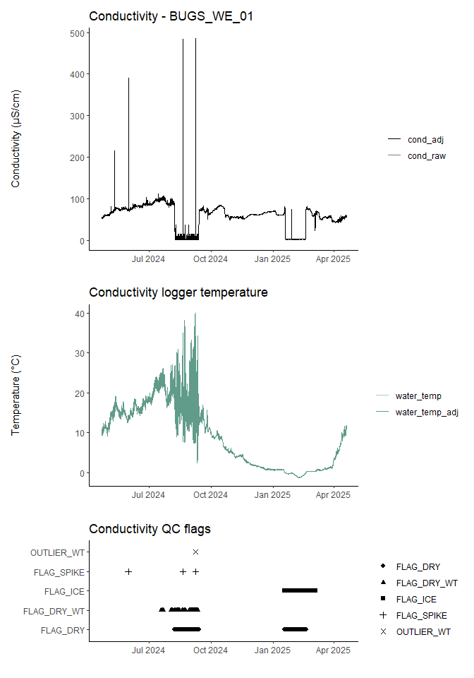

```r
plot_qc_timeseries(
  cond_data      = cond_qc,
  select_station = "BUGS_WE_01",
  static = TRUE
)
```

Compare the above plot with the output from running qc on data with air temperature. Notice the difference in `FLAG_DRY`.

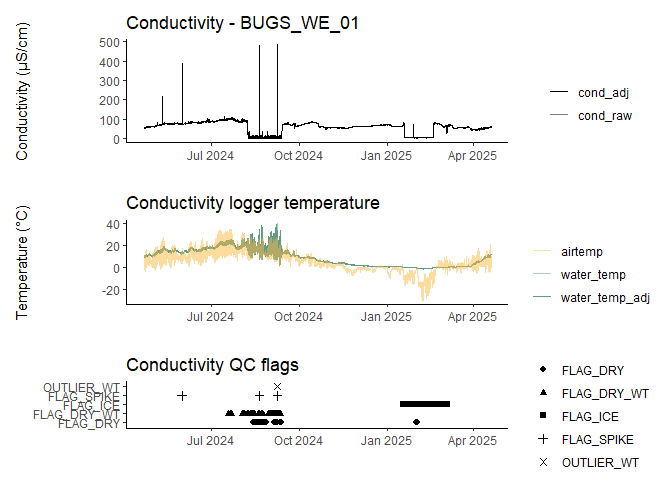

```r
plot_qc_timeseries(
  cond_data      = cond_qc_at,
  select_station = "BUGS_WE_01",
  static = TRUE
)
```

## STEP 4: Temperature Compensation (Specific Conductance)

Converts electrical conductivity (EC) to specific conductance (SPC) normalized to 25 °C.

Conductivity changes with water temperature — warmer water conducts electricity better. A reading of 100 µS/cm at 10 °C represents a different amount of dissolved ions than 100 µS/cm at 25 °C. Specific conductance removes this temperature effect, making it possible to:

- Compare readings across seasons (cold winter vs warm summer)
- Compare readings between sites at different temperatures
- Detect real water chemistry changes vs temperature changes

The math follows EN 27888 (British Standards Institution 1993), using a 5th-order polynomial to model the temperature dependence of conductivity. The function calculates what the conductivity would be if the water were at exactly 25 °C.

**Important:** This function can be run prior or after automated QA/QC, but in any raw values have been adjusted (i.e., shifted and *not* set to `NA`), this should be re-run so the temperature compensation uses the corrected conductivity values.

```r
cond_qc_spc <- convert_conductivity_spc_uScm(cond_qc_at)
```

```
#> Temperature compensation complete.
#> Raw conductivity range:    0.8 to 486.3 uS/cm
#> Specific conductance range: 0.9 to 690.6 uS/cm @ 25C
```

```
#> Sample comparison (EC vs SPC at varying temperatures):
#> # A tibble: 6 × 4
#>   timestamp           watertemp_C_adj conduct_uScm_adj spc_uScm_adj
#>   <dttm>                        <dbl>            <dbl>        <dbl>
#> 1 2024-04-21 12:00:00            9.93             52.9         75.7
#> 2 2024-07-03 02:00:00           17.9              86.1        101.
#> 3 2024-09-13 16:00:00           13.2              72.6         95.4
#> 4 2024-11-25 06:00:00            2.39             58.9        105.
#> 5 2025-02-05 20:00:00           -1.1               2.2          4.4
#> 6 2025-04-19 11:00:00           11.0              59           81.9
```

## STEP 5: Manual Adjustments (Examples)

This section demonstrates how to manually remove bad data. Apply these only after reviewing the plot and identifying specific problem periods.

For conductivity data, the three reasons for removal are:

- **“ice”** — sensor frozen; conductivity unreliable. Sets `conduct_uScm_adj`, `watertemp_C_adj`, and (optionally) `spc_uScm_adj` to `NA`.
- **“dry”** — sensor out of water; readings are meaningless. Sets `conduct_uScm_adj` and `watertemp_C_adj`, and (optionally) `spc_uScm_adj` to `NA`.
- **“disturbance”** — physical disturbance. Sets `conduct_uScm_adj` and `watertemp_C_adj`, and (optionally) `spc_uScm_adj` to `NA`.

### Remove a dry period

```r
cond_qc_adj <- adjust_logger_NA(
  input_data       = cond_qc_spc,
  select_station   = "BUGS_WE_01",
  metric           = "conductivity",
  reason_to_adjust = "dry",
  timestamp_start  = "2024-08-07 14:00:00",
  timestamp_end    = "2024-09-12 12:00:00",
  manual_note      = "Sensor exposed during low water"
)
```

### Remove an ice period

```r
cond_qc_adj <- adjust_logger_NA(
  input_data       = cond_qc_adj,
  select_station   = "BUGS_WE_01",
  metric           = "conductivity",
  reason_to_adjust = "ice",
  timestamp_start  = "2025-01-17 02:00:00",
  timestamp_end    = "2025-02-18 11:00:00",
  manual_note      = "Sensor encased in ice"
)
```

### Remove a disturbance

```r
cond_qc_adj <- adjust_logger_NA(
  input_data       = cond_qc_adj,
  select_station   = "BUGS_WE_01",
  metric           = "conductivity",
  reason_to_adjust = "disturbance",
  timestamp_start  = "2024-05-31 03:50:00",
  timestamp_end    = "2024-05-31 04:10:00",
  manual_note      = "Remove sensor spike"
)
```

### Review

After any manual adjustments, always re-plot to verify:

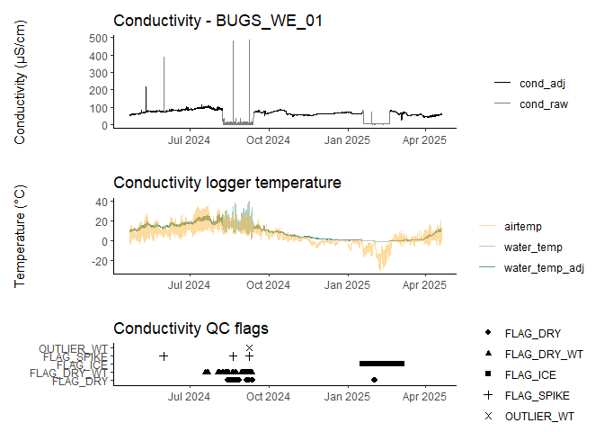

```r
plot_qc_timeseries(
  cond_data      = cond_qc_adj,
  select_station = "BUGS_WE_01",
  static         = TRUE
)
```

## STEP 6: Export Clean Data

Writes the final processed data to a v1.0 CSV file, one file per station per year, stored in `<output_folder>/<year>/clean/`.

**Columns written::*

- Required: `conduct_uScm` (raw, never modified)
- Optional (if present): `conduct_uScm_adj`, `spc_uScm_adj`, `watertemp_C`, `watertemp_C_adj`
- Auto-included: `qc_code` column

```r
output_folder <- file.path(tempdir(), "conductivity_output")

write_clean_data(
  input_data            = cond_qc_adj,
  path_to_output_folder = output_folder,
  metric                = "conductivity"
)
```

## Recap

| Step | Function | Result |
| --- | --- | --- |
| 1 | `bind_logger_files()` on COND | `cond_data` (raw conductivity) |
| 2 | `qc_conductivity()` | `cond_qc` (auto QC’d) |
| 3 | `plot_qc_timeseries()` | (visual review) |
| 4 | `convert_conductivity_spc_uScm()` | `cond_qc_spc` (adds SPC) |
| 5 | Manual adjustments | `cond_qc_adj` (updated) |
| 6 | Export | CSV file |

**Key columns:**

- `conduct_uScm` — raw electrical conductivity (never modified)
- `conduct_uScm_adj` — adjusted EC (QC + drift corrections applied)
- `spc_uScm_adj` — specific conductance at 25 °C (temp-compensated)
- `watertemp_C` — raw water temperature (never modified)
- `watertemp_C_adj` — adjusted water temperature
- `qc_code` — Data quality status indicator

| Code | Translation |
| --- | --- |
| `REAL` | Verified and accurate |
| `REMOVED` | Removed via automatic or manual QC |
| `NA` | Data produced a logger error code |
| `CORRECTED` | Manually adjusted (shifted, not removed) |
| `DRY` | Manually removed due to a dry event |

For analysis, use `spc_uScm_adj` — it’s the fully corrected, temperature-compensated specific conductance. Compare with `conduct_uScm` to see what the processing changed.